```python
import pandas as pd
from datetime import datetime
import statistics
import seaborn as sns
from matplotlib import rcParams
import warnings
warnings.filterwarnings("ignore")
from functools import reduce
import math
import matplotlib.pyplot as plt
import numpy as np
import matplotlib as mpl

rcParams['figure.figsize'] = 14,7

df = pd.read_csv('C:/Users/LT17/Python/Auxiliary/noise_data_test.csv')

df.timestamp = pd.to_datetime(df.timestamp)
df['month'] = df.timestamp.dt.month
df.max_slow = round(df.max_slow,2)
df.drop(columns=['Unnamed: 0'], inplace=True)

print('Есть ли NaN в датасете: '+str(df.isna().values.any()) + '\n' + 'Объём выборки: '+ str(df.shape))
```

```
Есть ли NaN в датасете: False
Объём выборки: (6673, 5)
```

```python
from sklearn.preprocessing import LabelEncoder
le = LabelEncoder()
label = le.fit_transform(df['type'])
df['type'] = label
```

# 1. Оценить тип математического распределения представленных значений: бимодальное.

# Как видно из приведенной ниже гистограммы, биномиальное оно потому, что в течение анализируемого периода плотность распределения уровня шума менялась: в апреле мода признака была в районе 73 дбА, в мае ~67 дбА. На последующих диаграммах будет видно, что причиной данного явления стало изменение в мерах центральной тенденции для самолётов с наибольшим количеством полётов за рассматриваемый период: Boeing 737-800, Boeing 737-500, Sukhoi Superjet и т.д. В апреле они в среднем создавали более высокий показатель шума, чем в мае, тем самым сместив "центр тяжести" для всей анализируемой выборки.

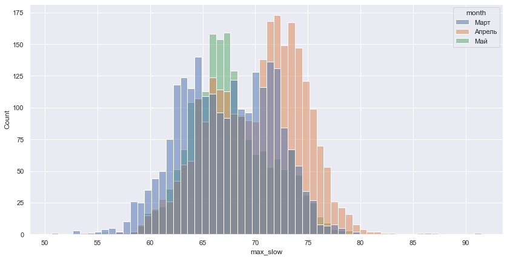

```python
df.month.replace({3: 'Март', 4: "Апрель", 5: "Май"}, inplace = True)
sns.histplot(data = df, hue = 'month', x = 'max_slow', bins = 60)
```

# 1.1. Feature engineering

```python
df['hours'] = df['timestamp'].dt.hour
df['daylight'] = ((df['hours'] >= 8) & (df['hours'] <= 22)).astype(int)

# the day of the week (Monday=0, Sunday=6) and if it's a week end day or week day.
df['DayOfTheWeek'] = df['timestamp'].dt.dayofweek
df['WeekDay'] = (df['DayOfTheWeek'] < 5).astype(int)
```

```python
df['time_epoch'] = (df['timestamp'].astype(np.int64)/100000000000).astype(np.int64)
```

```python
# creation of 4 distinct categories that seem useful (week end/day week & night/day)
df['categories'] = df['WeekDay']*2 + df['daylight']

a = df.loc[df['categories'] == 0, 'max_slow']
b = df.loc[df['categories'] == 1, 'max_slow']
c = df.loc[df['categories'] == 2, 'max_slow']
d = df.loc[df['categories'] == 3, 'max_slow']
```

# 1.2. Распределение уровня шума по дню недели (будний или выходной) и по времени суток (ночное или дневное время)

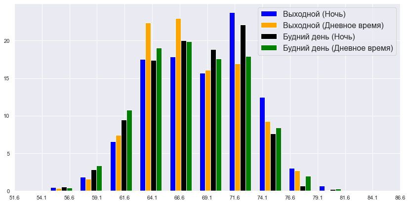

```python
fig, ax = plt.subplots()


a_heights, a_bins = np.histogram(a)
b_heights, b_bins = np.histogram(b, bins=a_bins)
c_heights, c_bins = np.histogram(c, bins=a_bins)
d_heights, d_bins = np.histogram(d, bins=a_bins)



width = (a_bins[1] - a_bins[0])/5.5

ax.bar(a_bins[:-1], a_heights*100/a.count(), width=width, facecolor='blue', label='Выходной (Ночь)', align='center')
ax.bar(b_bins[:-1]+width, (b_heights*100/b.count()), width=width, facecolor='orange', label ='Выходной (Дневное время)', align='center')
ax.bar(c_bins[:-1]+width*2, (c_heights*100/c.count()), width=width, facecolor='black', label ='Будний день (Ночь)', align='center')
ax.bar(d_bins[:-1]+width*3, (d_heights*100/d.count()), width=width, facecolor='green', label ='Будний день (Дневное время)', align='center')

plt.xticks(np.arange(min(df.max_slow)+1, max(df.max_slow)-4, 2.5))

rcParams['figure.figsize'] = 17,8

plt.legend(fontsize = 16)
plt.show()
```

# На основе представленных данных можем утверждать: если взять все наблюдения с уровнем шума > 70 дбА (то есть выше среднего по выборке в целом), то чаще всего они были зафиксированы в выходные дни и - более того - в ночное время.

# Аналогичным образом - довольно часто фиксировались шумы в диапазоне 71-72 дбА в ночное время в будние дни.

# 1.3. Гистограммы распределения уровня шума для каждой модели c cуммарным количеством полётов >30

# Ось X cпециально унифицирована для всех графиков, чтобы было видно, как распределен признак уровня звука у моделей относительно друг друга

# Также на 3 отдельных столбца выведена плотность распределения исследуемого признака по месяцам

```python
# Функция расчёта среднего уровня звука
def dba_mean(series):

    series.sort_values(ascending=False)

    if series.max() - series.min() < 7:
        return series.mean()

    else:
        return reduce(lambda x, y: 10*math.log10(10**(x*0.1)+ 10**(y*0.1)), series) - 10 * math.log10(series.shape[0])
# dba_mean - расчёт среднего значения уровня звука по формуле с логарифмом. ср. арифм и медиана приведены для сравнения
planes_mean_db_stat = df.groupby(['type', 'model']).agg({'max_slow': [dba_mean, 'mean', 'median','count']}).sort_values(by = [('max_slow', 'count')], ascending=False)
planes_mean_db_stat.columns = planes_mean_db_stat.columns.droplevel()
# planes_mean_db_stat.query('count > 100')

def mean_line(data, var=None, **kws):
    if not var: return

    m = dba_mean(data[var])

    ax = plt.gca()

    ax.axvline(m, color = 'maroon', lw = 3, ls='--')

    x_pos=0.7
    ax.text(x_pos, 0.7, f'mean(lg)={m:.1f}',
            transform = ax.transAxes,
            color='maroon', fontweight = 'bold', fontsize=17)
```

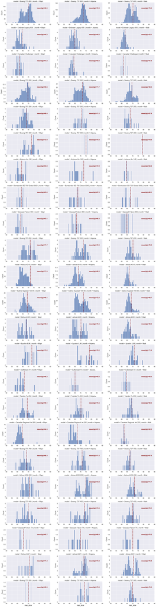

```python
mpl.rc("figure", figsize=(45, 10))

df2 = df.groupby('model').agg({'model': 'count'}).rename(columns={'model': 'count'}).sort_values(by='count', ascending = True)
df2 = df2.where(lambda x: x < 30).dropna()
# Убираем из изначального датафрейма все данные по самолётам, у которых суммарно было зарегистрированo менее 10 полетов
df2 = df[~df['model'].isin(df2.index)]
df2.month.replace({3: 'Март', 4: "Апрель", 5: "Май"}, inplace = True)

sns.set(font_scale=1.5) # Размер всего текста в графиках

g = sns.FacetGrid(data = df2, row='model',
                  col = 'month',
                  size = 4,
                  palette = 'rocket_r',
                  aspect=2,
                  sharex = False,
                  sharey = False,
                  xlim = (50,90),
                  height = 3.35)

g.map(sns.histplot, 'max_slow', bins=30)
g.map_dataframe(mean_line, var = 'max_slow')
plt.show()
```

# Анализируя графики, представляется обоснованным утверждение о том, что изменение характера плотности распределения уровня звука между отдельно взятыми месяцами должно быть связано преимущественно с изменением траектории полёта, характером набора высоты самолётами, а не влиянием посторонних источников звука.

# Тем не менее, даже исходя из графического анализа плотности распределения уровня звука, заметны существенные отклонения некоторых наблюдений от средних тенденций, - например для Canadair Regional Jet 200 (В Марте и Апреле), Gulfstream IV в Марте, Sukhoi Superjet в Апреле и т.д.